# Final Project

```r
# Libraries
library(renv)
library(RODBC)
library(boot)
library(lares)
library(psych)
library(lme4)
library(olsrr)
library(lmtest)
library(ggpubr)
library(ggplot2)
library(survival)
library(ggfortify)
library(survminer)
library(tidyverse)
library(ggfortify)
library(DescTools)
library(ggfortify)
library(ggcorrplot)
library(tidymodels)
library(patchwork)
```

# Phase 1 - (40%)

- The company want to create a model that predicts the probability of a New Client to repurchase in the Month 5, based on their transactional behavior during the first month (considering the first month as M0).

```r
# Loading dataset with the first month activity for every client
data1 <- readxl::read_excel("./Data/clients_first_month_VF.xlsx", sheet = "db")

# Changing the variables types
data1$id <- as.numeric(data1$id)
data1$age_gen <- as.factor(data1$age_gen)
data1$date_order <- as.Date(data1$date_order)
data1$MXN <- as.numeric(data1$MXN)
data1$products <- as.numeric(data1$products)

head(data1)
```

| id | market | age_gen | order | date_order | MXN | products |
| --- | --- | --- | --- | --- | --- | --- |
| 1 | English | Millennials | 1_1 | 2021-03-16 | 26.530 | 2 |
| 1 | English | Millennials | 1_2 | 2021-03-28 | 190.925 | 12 |
| 2 | English | Millennials | 2_1 | 2021-03-31 | 184.975 | 8 |
| 3 | English | Millennials | 3_1 | 2021-03-14 | 358.855 | 19 |
| 4 | English | Millennials | 4_1 | 2021-03-29 | 121.310 | 6 |
| 5 | Spanish | Generation X | 5_1 | 2021-03-20 | 40.145 | 4 |

```r
# Loading dataset with the first month activity for every client
data2 <- readxl::read_excel("./Data/clients_18months_VF.xlsx", sheet = "db")

# Changing the variables types
data2$id <- as.numeric(data2$id)
data2$month <- as.factor(data2$month)
data2$MXN <- as.numeric(data2$MXN)

head(data2)
```

| id | month | MXN |
| --- | --- | --- |
| 1 | M0 | 217.455 |
| 1 | M1 | 450.730 |
| 1 | M2 | 732.886 |
| 1 | M3 | 389.298 |
| 1 | M4 | 921.466 |
| 1 | M5 | 265.958 |

## 1.1) Aditional variables to calculate:

- Recency: Days since last order considerig the end of the period as 31/03/2021.
- Frequency: Number of orders in the first month.
- Order Size: AVG MXN of the orders in their first month
- Total MXM: Total MXN spend in the first month.

```r
# Making the variables for the first dataset
data1 <- data1 %>%
  group_by(id, market, age_gen) %>%
  summarise(max_month = max(date_order),
            recency = as.numeric(difftime(as.Date("2021-03-31"), max_month, units = "days")),
            frequency = as.numeric(n()),
            order_size = as.numeric(mean(MXN)),
            total_MXN = as.numeric(sum(MXN))
            )

data1 <- data1 %>% select(-max_month)
data1$market <- as.factor(data1$market)
summary(data1)
```

```
       id           market             age_gen        recency         frequency
 Min.   :   1   English:1629   Boomers     :  57   Min.   : 0.000   Min.   :  1.00
 1st Qu.: 518   Spanish: 440   Generation X: 485   1st Qu.: 1.000   1st Qu.:  1.00
 Median :1035                  Generation Z: 388   Median : 4.000   Median :  2.00
 Mean   :1035                  Millennials :1139   Mean   : 6.438   Mean   :  2.96
 3rd Qu.:1552                                      3rd Qu.: 9.000   3rd Qu.:  3.00
 Max.   :2069                                      Max.   :30.000   Max.   :127.00
   order_size        total_MXN
 Min.   :   2.10   Min.   :   2.1
 1st Qu.:  59.60   1st Qu.: 102.8
 Median :  99.96   Median : 201.5
 Mean   : 154.76   Mean   : 351.0
 3rd Qu.: 175.59   3rd Qu.: 422.6
 Max.   :1012.00   Max.   :4047.5
```

```r
# Making the objective variable
data1_5 <- data2 %>%
  filter(month == "M5") %>%
  mutate(status = ifelse (MXN > 0, 1, 0))

# Selecting the columns that we need
data1_5 <- data1_5 %>% select(id, status)
data1_5$status <- as.factor(data1_5$status)
data1_5
```

| id | status |
| --- | --- |
| 1 | 1 |
| 2 | 0 |
| 3 | 0 |
| 4 | 0 |
| 5 | 0 |
| 6 | 1 |
| 7 | 1 |
| 8 | 1 |
| 9 | 1 |
| 10 | 1 |

[output cut: 990 more lines]

```r
# Merging both dataset
data1 <- merge(data1, data1_5, by="id")
data1
```

| id | market | age_gen | recency | frequency | order_size | total_MXN | status |
| --- | --- | --- | --- | --- | --- | --- | --- |
| 1 | English | Millennials | 3 | 2 | 108.72750 | 217.455 | 1 |
| 2 | English | Millennials | 0 | 1 | 184.97500 | 184.975 | 0 |
| 3 | English | Millennials | 17 | 1 | 358.85500 | 358.855 | 0 |
| 4 | English | Millennials | 2 | 1 | 121.31000 | 121.310 | 0 |
| 5 | Spanish | Generation X | 11 | 1 | 40.14500 | 40.145 | 0 |
| 6 | Spanish | Millennials | 0 | 2 | 59.97250 | 119.945 | 1 |
| 7 | Spanish | Millennials | 1 | 3 | 64.30667 | 192.920 | 1 |
| 8 | Spanish | Generation X | 8 | 4 | 456.75000 | 1827.000 | 1 |
| 9 | English | Generation X | 6 | 2 | 90.51000 | 181.020 | 1 |
| 10 | Spanish | Generation X | 9 | 1 | 73.74500 | 73.745 | 1 |

[output cut: 990 more lines]

## 1.2) Develop a data exploration.

### 1.2.1) Categorical variables

```r
categoric_df <- data1 %>% select(market,age_gen)
summary(categoric_df)
```

```
     market             age_gen
 English:1629   Boomers     :  57
 Spanish: 440   Generation X: 485
                Generation Z: 388
                Millennials :1139
```

- We have only two categorical variables without null values and with a low granularity.

```r
initial_props <- data1 %>% count(status) %>% mutate(Balance= n/sum(n)) %>% filter(status==1)
initial_props
```

| status | n | Balance |
| --- | --- | --- |
| 1 | 844 | 0.4079265 |

[figure not shown]

```r
market_props <- data1 %>% group_by(market) %>%  count(status) %>% mutate(proportion = n/sum(n)) %>% filter(status==1)

ggplot(market_props,aes(x=market, y=proportion)) + geom_point(size = 3.7, colour= c("blue", "red")) + geom_hline(yintercept=0.4079265, linetype="dashed", color = "red", linetype = 'Proportion of all data') +
                                          labs( title = 'Percentage of clients who repurchased',
                                          x = 'Categories of the "Market" variable',
                                          y = "%")
```

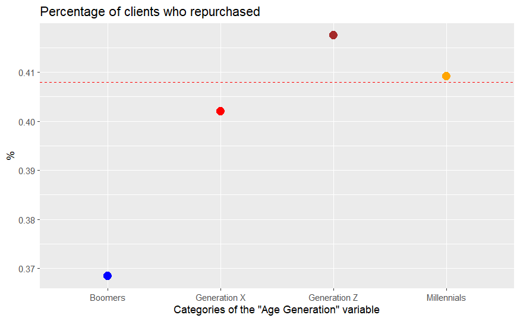

```r
gen_props <- data1 %>% group_by(age_gen) %>%  count(status) %>% mutate(proportion = n/sum(n)) %>% filter(status==1)

ggplot(gen_props,aes(x=age_gen, y=proportion)) +
  geom_point(size = 3.7, colour= c("blue", "red", 'Brown','Orange')) +
  geom_hline(yintercept=0.4079265, linetype="dashed", color = "red", linetype = 'Proportion of all data') +
  labs( title = 'Percentage of clients who repurchased',
        x = 'Categories of the "Age Generation" variable',
        y = "%")
```

Analyzing the second categorical variable and based on the previous visualization there is a good chance that “Boomers” and “Generation Z” end up being good predictors because of it’s difference on the proportion of customers who repurchased compared to the other categories and the general proportion.

### 1.2.2) Numerical variables

```r
numeric_df <- data1 %>% select(-c(market,age_gen,status))
summary(numeric_df)
```

```
       id          recency         frequency        order_size        total_MXN
 Min.   :   1   Min.   : 0.000   Min.   :  1.00   Min.   :   2.10   Min.   :   2.1
 1st Qu.: 518   1st Qu.: 1.000   1st Qu.:  1.00   1st Qu.:  59.60   1st Qu.: 102.8
 Median :1035   Median : 4.000   Median :  2.00   Median :  99.96   Median : 201.5
 Mean   :1035   Mean   : 6.438   Mean   :  2.96   Mean   : 154.76   Mean   : 351.0
 3rd Qu.:1552   3rd Qu.: 9.000   3rd Qu.:  3.00   3rd Qu.: 175.59   3rd Qu.: 422.6
 Max.   :2069   Max.   :30.000   Max.   :127.00   Max.   :1012.00   Max.   :4047.5
```

Recency:

- The 50% of the clients had 4 days since last order considering the end of the period as 31/03/2021
- The maximum value for this variable is 30, from this moment we may think that customers with values like this one could have less probabilities to repurchase

```r
# Layout to split the screen
layout(mat = matrix(c(1,2),2,1, byrow=TRUE),  height = c(1,8))

# Draw the boxplot and the histogram
par(mar=c(0, 3.1, 1.1, 2.1))
boxplot(numeric_df$recency, horizontal=TRUE , ylim=c(0,30), xaxt="n" , col=rgb(0.8,0.8,0,0.5) , frame=F)
par(mar=c(4, 3.1, 1.1, 2.1))
```

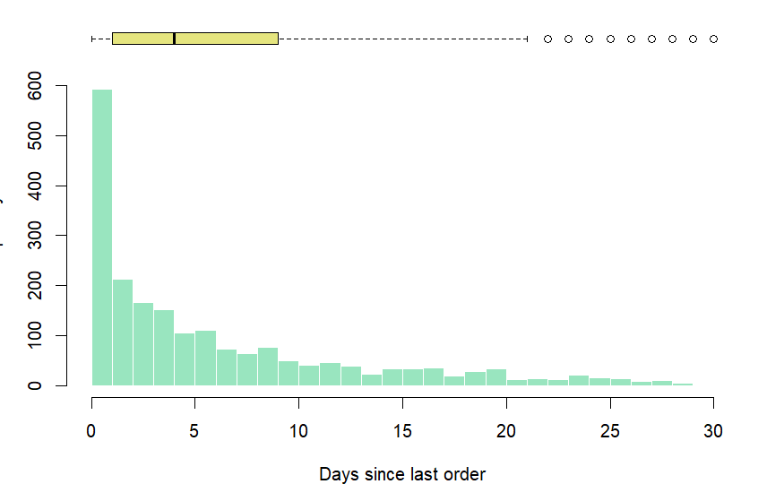

```r
hist(numeric_df$recency , breaks=40 , col=rgb(0.2,0.8,0.5,0.5) , border=F , main="" , xlab="Days since last order", xlim=c(0,30))
```

Frecuency:

- 75% of the customers had 3 or less number of orders in the first month.

```r
# Layout to split the screen
layout(mat = matrix(c(1,2),2,1, byrow=TRUE),  height = c(1,8))

# Draw the boxplot and the histogram
par(mar=c(0, 3.1, 1.1, 2.1))
boxplot(numeric_df$frequency, horizontal=TRUE , ylim=c(0,30), xaxt="n" , col=rgb(0.8,0.8,0,0.5) , frame=F)
par(mar=c(4, 3.1, 1.1, 2.1))
```

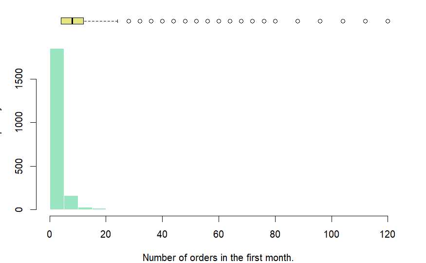

```r
hist(numeric_df$frequency , breaks=40 , col=rgb(0.2,0.8,0.5,0.5) , border=F , main="" , xlab="Number of orders in the first month.", xlim=c(0,120))
```

Order Size:

- 75% of the customers had an average of $175.59 or less in their orders in the first month.
- As we can see The mean is greater more than 50% than the median, and we have a maximum value of $1012, that’s probabliy because we could have outliers in that variable

```r
# Layout to split the screen
layout(mat = matrix(c(1,2),2,1, byrow=TRUE),  height = c(1,8))

# Draw the boxplot and the histogram
par(mar=c(0, 3.1, 1.1, 2.1))
boxplot(numeric_df$order_size, horizontal=TRUE , ylim=c(0,1012), xaxt="n" , col=rgb(0.8,0.8,0,0.5) , frame=F)
par(mar=c(4, 3.1, 1.1, 2.1))
```

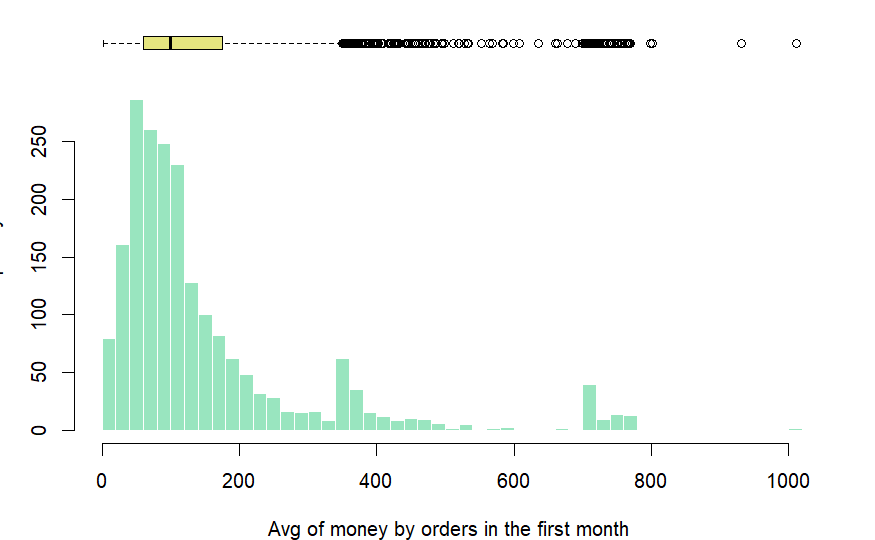

```r
hist(numeric_df$order_size , breaks=40 , col=rgb(0.2,0.8,0.5,0.5) , border=F , main="" , xlab="Avg of money by orders in the first month", xlim=c(0,1012))
```

Total MXN:

- 75% of the customers spend $422.6 or less in their first month.
- The mean is greater more than 70% than the median, and we have a maximum value of 4047, we may have outliers in this variable too.

```r
# Layout to split the screen
layout(mat = matrix(c(1,2),2,1, byrow=TRUE),  height = c(1,8))

# Draw the boxplot and the histogram
par(mar=c(0, 3.1, 1.1, 2.1))
boxplot(numeric_df$total_MXN, horizontal=TRUE , ylim=c(0,4047), xaxt="n" , col=rgb(0.8,0.8,0,0.5) , frame=F)
par(mar=c(4, 3.1, 1.1, 2.1))
```

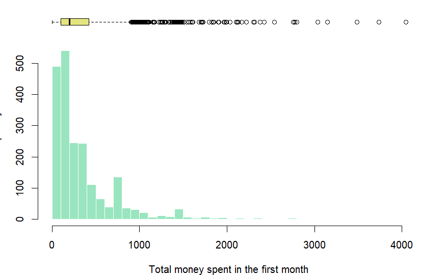

```r
hist(numeric_df$total_MXN , breaks=40 , col=rgb(0.2,0.8,0.5,0.5) , border=F , main="" , xlab="Total money spent in the first month", xlim=c(0,4047))
```

The most correlated variables are order_size + total_MXN which makes sense as the order size increase, the cost of it increases too. We are not going to remove any of those highly correlated variables as we only have a few variables to work with and they are not correlated enough in order to think that they are going to bring us problems in our model.

Top correlations

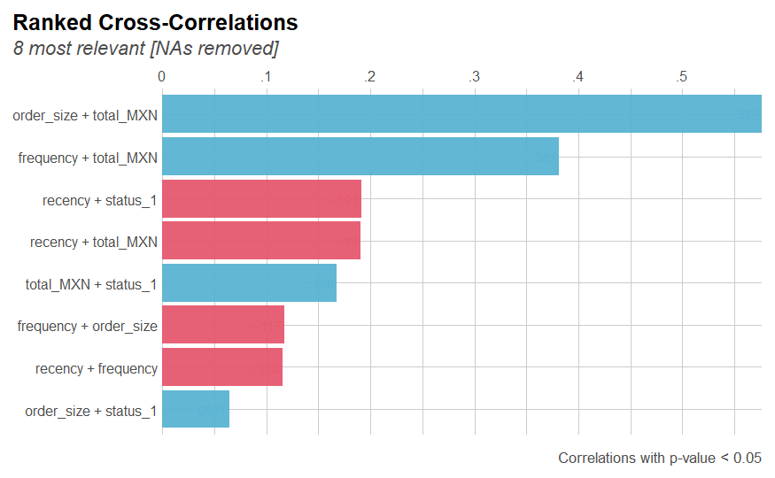

```r
corr_cross(select(data1,recency,frequency,order_size,total_MXN,status), rm.na = T, max_pvalue = 0.05, top = 15, grid = T)
```

From this correlation analysis the numeric variable most probable to have influence in our model is recency.

## 1.3) Develop a logistic regression in order to solve the problem. (The split of train and test is up to you)

```r
# Response variable balance
data1 %>% count(status) %>% mutate(Balance= n/sum(n))
```

| status | n | Balance |
| --- | --- | --- |
| 0 | 1225 | 0.5920735 |
| 1 | 844 | 0.4079265 |

```r
# Train and test
set.seed(10)

split_inicial<- initial_split(
                data = data1 %>% select(-(id)),
                prop = 0.8,
                strata = status
                )

train <- training(split_inicial)
test <- testing(split_inicial)

# Training the model
logistic <- glm(status ~ ., data=train, family="binomial")
summary(logistic)
```

```
Call:
glm(formula = status ~ ., family = "binomial", data = train)

Deviance Residuals:
    Min       1Q   Median       3Q      Max
-2.0973  -1.0394  -0.7599   1.2470   2.0208

Coefficients:
                      Estimate Std. Error z value Pr(>|z|)
(Intercept)         -0.2855482  0.3180646  -0.898   0.3693
marketSpanish       -0.2873436  0.1363852  -2.107   0.0351 *
age_genGeneration X  0.0959089  0.3224716   0.297   0.7661
age_genGeneration Z  0.1240196  0.3287807   0.377   0.7060
age_genMillennials   0.0728198  0.3135025   0.232   0.8163
recency             -0.0526714  0.0083163  -6.334 2.40e-10 ***
frequency           -0.0177152  0.0125571  -1.411   0.1583
order_size          -0.0005166  0.0004626  -1.117   0.2641
total_MXN            0.0009739  0.0002073   4.699 2.62e-06 ***
---
Signif. codes:  0 ‘***’ 0.001 ‘**’ 0.01 ‘*’ 0.05 ‘.’ 0.1 ‘ ’ 1

(Dispersion parameter for binomial family taken to be 1)

    Null deviance: 2237.8  on 1654  degrees of freedom
Residual deviance: 2132.5  on 1646  degrees of freedom
AIC: 2150.5

Number of Fisher Scoring iterations: 4
```

```r
test_results <- test
test_results$prob_model <- logistic%>% predict(test, type = "response")
    test_results$class_model <- as.factor(ifelse(test_results$prob_model >= 0.5, 1, 0))
# Accuracy
acc_model <-  accuracy(data = test_results,
                       truth    = status,
                       estimate = class_model)
acc_model <-acc_model$.estimate
print(paste0('Accuracy: ', acc_model))
```

```
[1] "Accuracy: 0.632850241545894"
```

```r
# Confusion Matrix
cm_model <- test_results %>%
  conf_mat(
    truth=status,
    estimate=class_model
    )

# Sensitivity
sen_model <- cm_model$table[4]/(cm_model$table[4]+cm_model$table[3])
print(paste0('Sensitivity: ', sen_model))
```

```
[1] "Sensitivity: 0.248520710059172"
```

```r
# Specificity
spe_model <- cm_model$table[1]/(cm_model$table[1]+cm_model$table[2])
print(paste0('Specificity: ', spe_model))
```

```
[1] "Specificity: 0.897959183673469"
```

```r
print('Confusion Matrix:')
```

```
[1] "Confusion Matrix:"
```

```r
cm_model
```

```
          Truth
Prediction   0   1
         0 220 127
         1  25  42
```

```
-   Consider as threshold 40%, 50% and 60%, present the performance for all the thresholds and select the best one (Justify your decision)
```

```r
# 40% threshold
test_results_40 <- test
test_results_40$prob_model <- logistic%>% predict(test, type = "response")
test_results_40$class_model <- as.factor(ifelse(test_results_40$prob_model >= 0.4, 1, 0))

# 50% threshold
test_results_50 <- test
test_results_50$prob_model <- logistic%>% predict(test, type = "response")
test_results_50$class_model <- as.factor(ifelse(test_results_50$prob_model >= 0.5, 1, 0))

# 60% threshold
test_results_60 <- test
test_results_60$prob_model <- logistic%>% predict(test, type = "response")
test_results_60$class_model <- as.factor(ifelse(test_results_60$prob_model >= 0.6, 1, 0))
```

Results:

```r
print("Treshold 40:")
```

```
[1] "Treshold 40:"
```

```r
# Confusion Matrix
cm_model_40 <- test_results_40 %>% conf_mat(
  truth=status,
  estimate=class_model)

# Accuracy
acc_model_40 <-  accuracy(data = test_results_40, truth = status,
                       estimate = class_model)$.estimate

print(paste0('Accuracy: ', acc_model_40))
```

```
[1] "Accuracy: 0.589371980676328"
```

```r
# Sensitivity
sen_model_40 <- cm_model_40$table[4]/(cm_model_40$table[4]+cm_model_40$table[3])
print(paste0('Sensitivity: ', sen_model_40))
```

```
[1] "Sensitivity: 0.710059171597633"
```

```r
# Specificity
spe_model_40 <- cm_model_40$table[1]/(cm_model_40$table[1]+cm_model_40$table[2])
print(paste0('Specificity: ', spe_model_40))
```

```
[1] "Specificity: 0.506122448979592"
```

```r
print("-----------------------------------------------------------------------")
```

```
[1] "-----------------------------------------------------------------------"
```

```r
print("Treshold 50:")
```

```
[1] "Treshold 50:"
```

```r
# Confusion Matrix
cm_model_50 <- test_results_50 %>% conf_mat(
  truth=status,
  estimate=class_model)

# Accuracy
acc_model_50 <-  accuracy(data = test_results_50, truth = status,
                       estimate = class_model)$.estimate

print(paste0('Accuracy: ', acc_model_50))
```

```
[1] "Accuracy: 0.632850241545894"
```

```r
# Sensitivity
sen_model_50 <- cm_model_50$table[4]/(cm_model_50$table[4]+cm_model_50$table[3])
print(paste0('Sensitivity: ', sen_model_50))
```

```
[1] "Sensitivity: 0.248520710059172"
```

```r
# Specificity
spe_model_50 <- cm_model_50$table[1]/(cm_model_50$table[1]+cm_model_50$table[2])
print(paste0('Specificity: ', spe_model_50))
```

```
[1] "Specificity: 0.897959183673469"
```

```r
print("-----------------------------------------------------------------------")
```

```
[1] "-----------------------------------------------------------------------"
```

```r
print("Treshold 60:")
```

```
[1] "Treshold 60:"
```

```r
# Confusion Matrix
cm_model_60 <- test_results_60 %>% conf_mat(
  truth=status,
  estimate=class_model)

# Accuracy
acc_model_60 <-  accuracy(data = test_results_60, truth = status,
                       estimate = class_model)$.estimate

print(paste0('Accuracy: ', acc_model_60))
```

```
[1] "Accuracy: 0.608695652173913"
```

```r
# Sensitivity
sen_model_60 <- cm_model_60$table[4]/(cm_model_60$table[4]+cm_model_60$table[3])
print(paste0('Sensitivity: ', sen_model_60))
```

```
[1] "Sensitivity: 0.0769230769230769"
```

```r
# Specificity
spe_model_60 <- cm_model_60$table[1]/(cm_model_60$table[1]+cm_model_60$table[2])
print(paste0('Specificity: ', spe_model_60))
```

```
[1] "Specificity: 0.975510204081633"
```

- Once that the threshold is selected, calculate the probability of repurchase for all the dataset (train and test) and based on the probability classify the new clients:
  - Above or equal to the threshold selected as “High Probability”
  - Less than 15% as “Low Probability”
  - The rest as “Medium Probability”

```r
# Selected Treshold
treshold_selec <- 0.5

# Removing the response
data_label <- data1
data_label <- data_label %>% select(-(status))

# Puting the probability into the dataset
data_label$Prob_Predicted <- logistic %>% predict(data_label, type = "response")

# Making a Label for each case
data_label$Prob_Predicted <- case_when(
    data_label$Prob_Predicted >= treshold_selec ~ "High Probability",
    data_label$Prob_Predicted <= 0.15 ~ "Low Probability",
    TRUE ~ "Medium Probability"
)

data_label
```

| id | market | age_gen | recency | frequency | order_size | total_MXN | Prob_Predicted |
| --- | --- | --- | --- | --- | --- | --- | --- |
| 1 | English | Millennials | 3 | 2 | 108.72750 | 217.455 | Medium Probability |
| 2 | English | Millennials | 0 | 1 | 184.97500 | 184.975 | Medium Probability |
| 3 | English | Millennials | 17 | 1 | 358.85500 | 358.855 | Medium Probability |
| 4 | English | Millennials | 2 | 1 | 121.31000 | 121.310 | Medium Probability |
| 5 | Spanish | Generation X | 11 | 1 | 40.14500 | 40.145 | Medium Probability |
| 6 | Spanish | Millennials | 0 | 2 | 59.97250 | 119.945 | Medium Probability |
| 7 | Spanish | Millennials | 1 | 3 | 64.30667 | 192.920 | Medium Probability |
| 8 | Spanish | Generation X | 8 | 4 | 456.75000 | 1827.000 | High Probability |
| 9 | English | Generation X | 6 | 2 | 90.51000 | 181.020 | Medium Probability |
| 10 | Spanish | Generation X | 9 | 1 | 73.74500 | 73.745 | Medium Probability |

[output cut: 990 more lines]

# Phase 2 - (40%)

- Generate a survival analysis for the new clients.

```r
data_2 <- readxl::read_excel("./Data/clients_18months_VF.xlsx")
data_2$month <- as.factor(data_2$month)

# Create numeric month variable
data_2$month_num <- sub("M", "", data_2$month)
data_2$month_num <- as.numeric(data_2$month_num)
head(data_2)
```

| id | month | MXN | month_num |
| --- | --- | --- | --- |
| 1 | M0 | 217.455 | 0 |
| 1 | M1 | 450.730 | 1 |
| 1 | M2 | 732.886 | 2 |
| 1 | M3 | 389.298 | 3 |
| 1 | M4 | 921.466 | 4 |
| 1 | M5 | 265.958 | 5 |

```r
summary(data_2)
```

```
       id           month            MXN            month_num
 Min.   :   1   M0     : 2069   Min.   :    0.0   Min.   : 0.0
 1st Qu.: 518   M1     : 2069   1st Qu.:    0.0   1st Qu.: 4.0
 Median :1035   M10    : 2069   Median :    0.0   Median : 8.5
 Mean   :1035   M11    : 2069   Mean   :  243.8   Mean   : 8.5
 3rd Qu.:1552   M12    : 2069   3rd Qu.:  157.8   3rd Qu.:13.0
 Max.   :2069   M13    : 2069   Max.   :27037.8   Max.   :17.0
                (Other):24828
```

- Consider as “dead” those who do not make a purchase in the month 18.

```r
data_fin <- data_2 %>% filter(MXN>0) %>% group_by(id)  %>%
  summarise(time_surv = max(month_num)) %>%
  mutate(status =case_when(
         time_surv == 17 ~ 0,
         TRUE ~ 1))

data_fin
```

| id | time_surv | status |
| --- | --- | --- |
| 1 | 17 | 0 |
| 2 | 11 | 1 |
| 3 | 7 | 1 |
| 4 | 12 | 1 |
| 5 | 17 | 0 |
| 6 | 17 | 0 |
| 7 | 17 | 0 |
| 8 | 17 | 0 |
| 9 | 5 | 1 |
| 10 | 11 | 1 |

[output cut: 990 more lines]

- Use the variables, age generation, market, probability label and recency and interpret the coeficients.

```r
# First, we have to merge the dataset with the probability labels with this dataset.
data_fin <- merge(data_label, data_fin)

# Now we apply a filter to keep the mention variables.
data_fin <- data_fin %>% select(c(id, age_gen, market, Prob_Predicted, recency, time_surv,status))
data_fin
```

| id | age_gen | market | Prob_Predicted | recency | time_surv | status |
| --- | --- | --- | --- | --- | --- | --- |
| 1 | Millennials | English | Medium Probability | 3 | 17 | 0 |
| 2 | Millennials | English | Medium Probability | 0 | 11 | 1 |
| 3 | Millennials | English | Medium Probability | 17 | 7 | 1 |
| 4 | Millennials | English | Medium Probability | 2 | 12 | 1 |
| 5 | Generation X | Spanish | Medium Probability | 11 | 17 | 0 |
| 6 | Millennials | Spanish | Medium Probability | 0 | 17 | 0 |
| 7 | Millennials | Spanish | Medium Probability | 1 | 17 | 0 |
| 8 | Generation X | Spanish | High Probability | 8 | 17 | 0 |
| 9 | Generation X | English | Medium Probability | 6 | 5 | 1 |
| 10 | Generation X | Spanish | Medium Probability | 9 | 11 | 1 |

[output cut: 990 more lines]

```r
data_fin$Prob_Predicted <- as.factor(data_fin$Prob_Predicted)
summary(data_fin)
```

```
       id               age_gen         market                Prob_Predicted    recency
 Min.   :   1   Boomers     :  57   English:1629   High Probability  : 352   Min.   : 0.000
 1st Qu.: 518   Generation X: 485   Spanish: 440   Low Probability   :   8   1st Qu.: 1.000
 Median :1035   Generation Z: 388                  Medium Probability:1709   Median : 4.000
 Mean   :1035   Millennials :1139                                            Mean   : 6.438
 3rd Qu.:1552                                                                3rd Qu.: 9.000
 Max.   :2069                                                                Max.   :30.000
   time_surv          status
 Min.   : 0.000   Min.   :0.0000
 1st Qu.: 2.000   1st Qu.:1.0000
 Median : 8.000   Median :1.0000
 Mean   : 8.493   Mean   :0.8091
 3rd Qu.:16.000   3rd Qu.:1.0000
 Max.   :17.000   Max.   :1.0000
```

### Model

```r
model <- coxph(Surv(time_surv, status) ~ age_gen + market + Prob_Predicted + recency, data = data_fin)
summary(model)
```

```
Call:
coxph(formula = Surv(time_surv, status) ~ age_gen + market +
    Prob_Predicted + recency, data = data_fin)

  n= 2069, number of events= 1674

                                       coef  exp(coef)   se(coef)      z Pr(>|z|)
age_genGeneration X              -0.0006771  0.9993231  0.1610168 -0.004    0.997
age_genGeneration Z               0.2153207  1.2402596  0.1623621  1.326    0.185
age_genMillennials                0.0175847  1.0177402  0.1561934  0.113    0.910
marketSpanish                    -0.0302240  0.9702281  0.0608812 -0.496    0.620
Prob_PredictedLow Probability     0.4075371  1.5031112  0.3749390  1.087    0.277
Prob_PredictedMedium Probability  0.2803901  1.3236460  0.0713109  3.932 8.43e-05 ***
recency                           0.0268272  1.0271903  0.0037072  7.236 4.61e-13 ***
---
Signif. codes:  0 ‘***’ 0.001 ‘**’ 0.01 ‘*’ 0.05 ‘.’ 0.1 ‘ ’ 1

                                 exp(coef) exp(-coef) lower .95 upper .95
age_genGeneration X                 0.9993     1.0007    0.7289     1.370
age_genGeneration Z                 1.2403     0.8063    0.9022     1.705
age_genMillennials                  1.0177     0.9826    0.7494     1.382
marketSpanish                       0.9702     1.0307    0.8611     1.093
Prob_PredictedLow Probability       1.5031     0.6653    0.7208     3.134
Prob_PredictedMedium Probability    1.3236     0.7555    1.1510     1.522
recency                             1.0272     0.9735    1.0198     1.035

Concordance= 0.591  (se = 0.008 )
Likelihood ratio test= 103.3  on 7 df,   p=<2e-16
Wald test            = 107  on 7 df,   p=<2e-16
Score (logrank) test = 108.9  on 7 df,   p=<2e-16
```

The 2 variables that we can interpretate are:

- *Prob_PredictedMedium Probability* $\Rightarrow$ The probability of not surviving increases 1.3236 times if you belong to the medium probability prediction label.
- *recency* $\Rightarrow$ The bigger it is the recency the probability of not surviving increases 1.0272 times

## Generate the survival curves based on the following.

### Graph 1 - Based on probability label

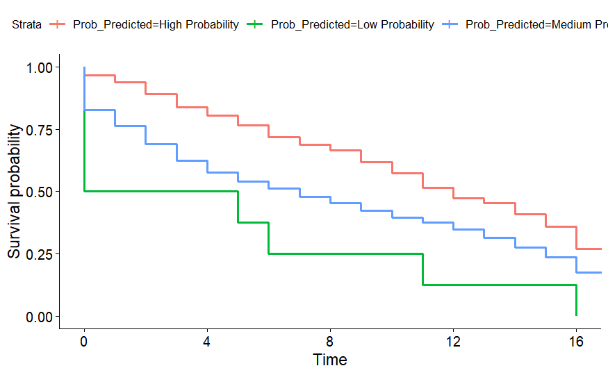

```r
ggsurvplot(survfit(Surv(time_surv, status) ~ Prob_Predicted , data = data_fin),data=data_fin)
```

The prediction performs well, low probability label is the one that survives the less, followed by medium label. The high probability label is the one that survives the most.

### Graph 2 - Based on market

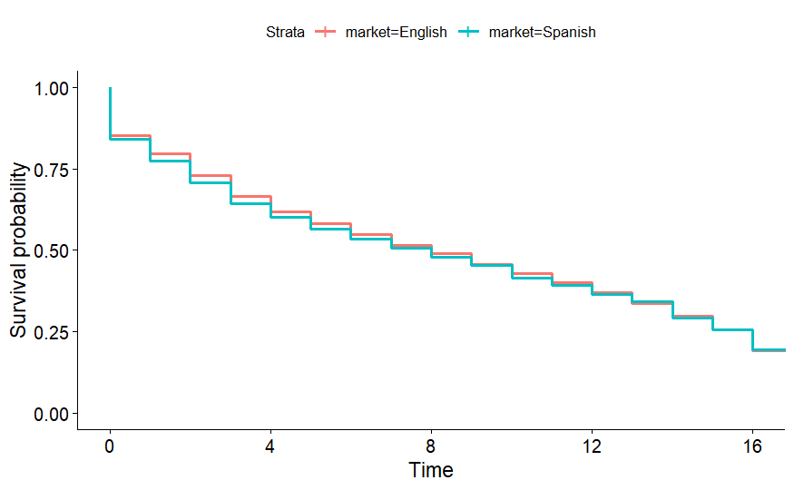

```r
ggsurvplot(survfit(Surv(time_surv, status) ~ market , data = data_fin),data=data_fin)
```

It doesn’t seem to be a difference between both markets.

These graphs show that the company should campaign with people who have the label of low and medium probability.